# Wine Quality Predictor

GOAL: To predict the quality of Wine based on certain parameters.

Data Source: Red Wine Quality Dataset - Kaggle ( https://www.kaggle.com/datasets/uciml/red-wine-quality-cortez-et-al-2009 )

We start by importing the data. { Required Library: Pandas }

```python
import pandas as pd
data = pd.read_csv(r"C:\Users\goura\Desktop\Data Science\Datasets\red-wine.csv")
data.head()
```

|  | fixed acidity | volatile acidity | citric acid | residual sugar | chlorides | free sulfur dioxide | total sulfur dioxide | density | pH | sulphates | alcohol | quality |
| --- | --- | --- | --- | --- | --- | --- | --- | --- | --- | --- | --- | --- |
| 0 | 7.4 | 0.70 | 0.00 | 1.9 | 0.076 | 11.0 | 34.0 | 0.9978 | 3.51 | 0.56 | 9.4 | 5 |
| 1 | 7.8 | 0.88 | 0.00 | 2.6 | 0.098 | 25.0 | 67.0 | 0.9968 | 3.20 | 0.68 | 9.8 | 5 |
| 2 | 7.8 | 0.76 | 0.04 | 2.3 | 0.092 | 15.0 | 54.0 | 0.9970 | 3.26 | 0.65 | 9.8 | 5 |
| 3 | 11.2 | 0.28 | 0.56 | 1.9 | 0.075 | 17.0 | 60.0 | 0.9980 | 3.16 | 0.58 | 9.8 | 6 |
| 4 | 7.4 | 0.70 | 0.00 | 1.9 | 0.076 | 11.0 | 34.0 | 0.9978 | 3.51 | 0.56 | 9.4 | 5 |

Lets get some info on the table.

```python
data.columns
```

```
Index(['fixed acidity', 'volatile acidity', 'citric acid', 'residual sugar',
       'chlorides', 'free sulfur dioxide', 'total sulfur dioxide', 'density',
       'pH', 'sulphates', 'alcohol', 'quality'],
      dtype='object')
```

```python
data.describe()
```

|  | fixed acidity | volatile acidity | citric acid | residual sugar | chlorides | free sulfur dioxide | total sulfur dioxide | density | pH | sulphates | alcohol | quality |
| --- | --- | --- | --- | --- | --- | --- | --- | --- | --- | --- | --- | --- |
| count | 1599.000000 | 1599.000000 | 1599.000000 | 1599.000000 | 1599.000000 | 1599.000000 | 1599.000000 | 1599.000000 | 1599.000000 | 1599.000000 | 1599.000000 | 1599.000000 |
| mean | 8.319637 | 0.527821 | 0.270976 | 2.538806 | 0.087467 | 15.874922 | 46.467792 | 0.996747 | 3.311113 | 0.658149 | 10.422983 | 5.636023 |
| std | 1.741096 | 0.179060 | 0.194801 | 1.409928 | 0.047065 | 10.460157 | 32.895324 | 0.001887 | 0.154386 | 0.169507 | 1.065668 | 0.807569 |
| min | 4.600000 | 0.120000 | 0.000000 | 0.900000 | 0.012000 | 1.000000 | 6.000000 | 0.990070 | 2.740000 | 0.330000 | 8.400000 | 3.000000 |
| 25% | 7.100000 | 0.390000 | 0.090000 | 1.900000 | 0.070000 | 7.000000 | 22.000000 | 0.995600 | 3.210000 | 0.550000 | 9.500000 | 5.000000 |
| 50% | 7.900000 | 0.520000 | 0.260000 | 2.200000 | 0.079000 | 14.000000 | 38.000000 | 0.996750 | 3.310000 | 0.620000 | 10.200000 | 6.000000 |
| 75% | 9.200000 | 0.640000 | 0.420000 | 2.600000 | 0.090000 | 21.000000 | 62.000000 | 0.997835 | 3.400000 | 0.730000 | 11.100000 | 6.000000 |
| max | 15.900000 | 1.580000 | 1.000000 | 15.500000 | 0.611000 | 72.000000 | 289.000000 | 1.003690 | 4.010000 | 2.000000 | 14.900000 | 8.000000 |

```python
data['quality'].value_counts()
```

```
quality
5    681
6    638
7    199
4     53
8     18
3     10
Name: count, dtype: int64
```

We now know about important statistics of all our attributes, as well as the label we want to predict - "quality"

Visualizing the data is important to gain insights about our data

For this, we can use: seaborn, matplotlib, pandas.plotting

An important information about each attribute is the correlation of its to the Label, as well as other attributes.

```python
corr_matrix = data.corr()
corr_matrix
```

|  | fixed acidity | volatile acidity | citric acid | residual sugar | chlorides | free sulfur dioxide | total sulfur dioxide | density | pH | sulphates | alcohol | quality |
| --- | --- | --- | --- | --- | --- | --- | --- | --- | --- | --- | --- | --- |
| fixed acidity | 1.000000 | -0.256131 | 0.671703 | 0.114777 | 0.093705 | -0.153794 | -0.113181 | 0.668047 | -0.682978 | 0.183006 | -0.061668 | 0.124052 |
| volatile acidity | -0.256131 | 1.000000 | -0.552496 | 0.001918 | 0.061298 | -0.010504 | 0.076470 | 0.022026 | 0.234937 | -0.260987 | -0.202288 | -0.390558 |
| citric acid | 0.671703 | -0.552496 | 1.000000 | 0.143577 | 0.203823 | -0.060978 | 0.035533 | 0.364947 | -0.541904 | 0.312770 | 0.109903 | 0.226373 |
| residual sugar | 0.114777 | 0.001918 | 0.143577 | 1.000000 | 0.055610 | 0.187049 | 0.203028 | 0.355283 | -0.085652 | 0.005527 | 0.042075 | 0.013732 |
| chlorides | 0.093705 | 0.061298 | 0.203823 | 0.055610 | 1.000000 | 0.005562 | 0.047400 | 0.200632 | -0.265026 | 0.371260 | -0.221141 | -0.128907 |
| free sulfur dioxide | -0.153794 | -0.010504 | -0.060978 | 0.187049 | 0.005562 | 1.000000 | 0.667666 | -0.021946 | 0.070377 | 0.051658 | -0.069408 | -0.050656 |
| total sulfur dioxide | -0.113181 | 0.076470 | 0.035533 | 0.203028 | 0.047400 | 0.667666 | 1.000000 | 0.071269 | -0.066495 | 0.042947 | -0.205654 | -0.185100 |
| density | 0.668047 | 0.022026 | 0.364947 | 0.355283 | 0.200632 | -0.021946 | 0.071269 | 1.000000 | -0.341699 | 0.148506 | -0.496180 | -0.174919 |
| pH | -0.682978 | 0.234937 | -0.541904 | -0.085652 | -0.265026 | 0.070377 | -0.066495 | -0.341699 | 1.000000 | -0.196648 | 0.205633 | -0.057731 |
| sulphates | 0.183006 | -0.260987 | 0.312770 | 0.005527 | 0.371260 | 0.051658 | 0.042947 | 0.148506 | -0.196648 | 1.000000 | 0.093595 | 0.251397 |
| alcohol | -0.061668 | -0.202288 | 0.109903 | 0.042075 | -0.221141 | -0.069408 | -0.205654 | -0.496180 | 0.205633 | 0.093595 | 1.000000 | 0.476166 |
| quality | 0.124052 | -0.390558 | 0.226373 | 0.013732 | -0.128907 | -0.050656 | -0.185100 | -0.174919 | -0.057731 | 0.251397 | 0.476166 | 1.000000 |

We can also plot this using a heatmap

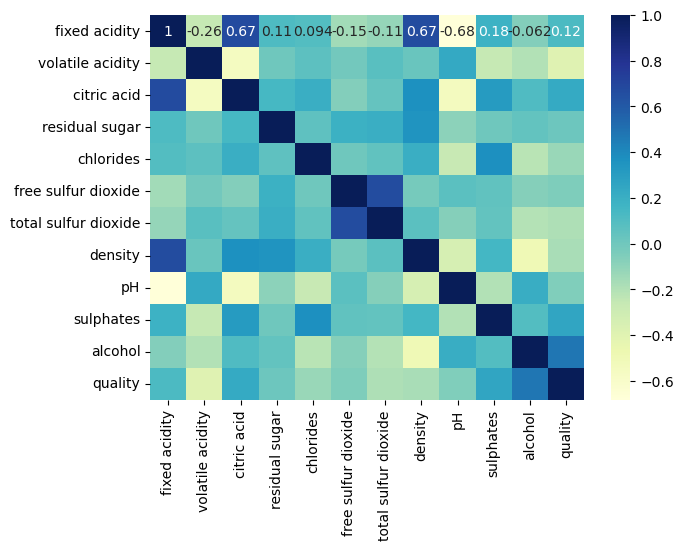

```python
import seaborn as sns
import matplotlib.pyplot as plt
plt.figure(figsize=(7,5))
sns.heatmap(corr_matrix,annot=True,cmap='YlGnBu')
```

The diagonal is to be ignored, as it signifies the correlation of one attribute to itself, which is, without exception, always 1 { highest possible value }. In this plot, the darker colours signify a higher correlation.

Now that we have visualized the data and have improved our understanding about it, we can proceed to pre-process the data for fitting into the desired model.

```python
features = data.columns[:-1].values         #all attributes except quality
label = data.columns[-1]                    #quality
```

It is good practice to split the available data into two parts, Train Set & Test Set. This is to evaluate the model trained on the Train Set by testing it on the Test Set. Otherwise, a model tested on the data its been trained on will give exceptional results, but may fail provide acceptable results when unknown data is introduced.

This tast has been made easier by Scikit-Learn, due to availability of: Random Sampling, Stratified Sampling

Random Sampling picks out Data Randomly, while Stratified Sampling picks out data which represents the Dataset as a whole. So, Stratified Sampling provides us with better data to train.

```python
from sklearn.model_selection import StratifiedShuffleSplit
split = StratifiedShuffleSplit(n_splits=1,test_size=0.2,random_state=42)
for train_index,test_index in split.split(data,data['quality']):
    train_set = data.loc[train_index]
    test_set = data.loc[test_index]
```

```python
train_set
```

|  | fixed acidity | volatile acidity | citric acid | residual sugar | chlorides | free sulfur dioxide | total sulfur dioxide | density | pH | sulphates | alcohol | quality |
| --- | --- | --- | --- | --- | --- | --- | --- | --- | --- | --- | --- | --- |
| 1542 | 6.7 | 0.855 | 0.02 | 1.90 | 0.064 | 29.0 | 38.0 | 0.99472 | 3.30 | 0.56 | 10.75 | 6 |
| 1558 | 6.9 | 0.630 | 0.33 | 6.70 | 0.235 | 66.0 | 115.0 | 0.99787 | 3.22 | 0.56 | 9.50 | 5 |
| 344 | 11.9 | 0.570 | 0.50 | 2.60 | 0.082 | 6.0 | 32.0 | 1.00060 | 3.12 | 0.78 | 10.70 | 6 |
| 924 | 8.6 | 0.470 | 0.27 | 2.30 | 0.055 | 14.0 | 28.0 | 0.99516 | 3.18 | 0.80 | 11.20 | 5 |
| 971 | 10.4 | 0.260 | 0.48 | 1.90 | 0.066 | 6.0 | 10.0 | 0.99724 | 3.33 | 0.87 | 10.90 | 6 |
| ... | ... | ... | ... | ... | ... | ... | ... | ... | ... | ... | ... | ... |
| 1056 | 8.9 | 0.480 | 0.53 | 4.00 | 0.101 | 3.0 | 10.0 | 0.99586 | 3.21 | 0.59 | 12.10 | 7 |
| 1394 | 6.4 | 0.570 | 0.14 | 3.90 | 0.070 | 27.0 | 73.0 | 0.99669 | 3.32 | 0.48 | 9.20 | 5 |
| 337 | 7.8 | 0.430 | 0.32 | 2.80 | 0.080 | 29.0 | 58.0 | 0.99740 | 3.31 | 0.64 | 10.30 | 5 |
| 539 | 11.2 | 0.500 | 0.74 | 5.15 | 0.100 | 5.0 | 17.0 | 0.99960 | 3.22 | 0.62 | 11.20 | 5 |
| 1083 | 8.7 | 0.420 | 0.45 | 2.40 | 0.072 | 32.0 | 59.0 | 0.99617 | 3.33 | 0.77 | 12.00 | 6 |

1279 rows × 12 columns

```python
test_set
```

|  | fixed acidity | volatile acidity | citric acid | residual sugar | chlorides | free sulfur dioxide | total sulfur dioxide | density | pH | sulphates | alcohol | quality |
| --- | --- | --- | --- | --- | --- | --- | --- | --- | --- | --- | --- | --- |
| 963 | 8.8 | 0.27 | 0.39 | 2.0 | 0.100 | 20.0 | 27.0 | 0.99546 | 3.15 | 0.69 | 11.2 | 6 |
| 475 | 9.6 | 0.68 | 0.24 | 2.2 | 0.087 | 5.0 | 28.0 | 0.99880 | 3.14 | 0.60 | 10.2 | 5 |
| 1 | 7.8 | 0.88 | 0.00 | 2.6 | 0.098 | 25.0 | 67.0 | 0.99680 | 3.20 | 0.68 | 9.8 | 5 |
| 329 | 10.7 | 0.46 | 0.39 | 2.0 | 0.061 | 7.0 | 15.0 | 0.99810 | 3.18 | 0.62 | 9.5 | 5 |
| 149 | 8.2 | 0.40 | 0.44 | 2.8 | 0.089 | 11.0 | 43.0 | 0.99750 | 3.53 | 0.61 | 10.5 | 6 |
| ... | ... | ... | ... | ... | ... | ... | ... | ... | ... | ... | ... | ... |
| 1173 | 7.6 | 0.36 | 0.31 | 1.7 | 0.079 | 26.0 | 65.0 | 0.99716 | 3.46 | 0.62 | 9.5 | 6 |
| 827 | 7.1 | 0.46 | 0.14 | 2.8 | 0.076 | 15.0 | 37.0 | 0.99624 | 3.36 | 0.49 | 10.7 | 5 |
| 356 | 11.5 | 0.41 | 0.52 | 3.0 | 0.080 | 29.0 | 55.0 | 1.00010 | 3.26 | 0.88 | 11.0 | 5 |
| 1287 | 8.0 | 0.60 | 0.08 | 2.6 | 0.056 | 3.0 | 7.0 | 0.99286 | 3.22 | 0.37 | 13.0 | 5 |
| 789 | 8.6 | 0.63 | 0.17 | 2.9 | 0.099 | 21.0 | 119.0 | 0.99800 | 3.09 | 0.52 | 9.3 | 5 |

320 rows × 12 columns

```python
wine_features_tr = train_set[features]
wine_label_tr = train_set["quality"]
wine_features_te=test_set[features]
wine_label_te=test_set["quality"]
```

Next, we need to handle:

-> Null values [ imputing / deletion ]

-> Categorical values [ encoding ]

Since our dataset doesnt have any categorical values, we dont have to worry about encoding.

For null values, all rows with null values can be dropped by using the dropna() function, but data is lost in that process. A better approach is the to fill in the null values using any parameter from the other values.

This can be done using the SimpleImputer from sklearn library.

Lets first check no of null values

```python
wine_features_tr.isna().sum()
```

```
fixed acidity           0
volatile acidity        0
citric acid             0
residual sugar          0
chlorides               0
free sulfur dioxide     0
total sulfur dioxide    0
density                 0
pH                      0
sulphates               0
alcohol                 0
dtype: int64
```

We have no null values, so we dont need Imputation either.

As we see, all the attributes here are numeric values, so we can use either of these three:

-> LinearRegressor

-> DesicionTreeRegressor

-> RandomForestRegressor

Lets start with LinearRegressor

```python
from sklearn.linear_model import LinearRegression
lin_reg = LinearRegression()
lin_reg.fit(wine_features_tr,wine_label_tr)
lin_pred = lin_reg.predict(wine_features_te)
lin_pred
```

```
array([6.32922267, 5.46660305, 5.1572968 , 5.5688065 , 5.58138071,
       6.03262132, 5.08478005, 4.4996503 , 5.51573986, 6.12624362,
       5.13294042, 5.47274026, 5.23882231, 5.23447299, 5.4457214 ,
       5.80529027, 5.24443432, 5.00866933, 6.5864237 , 6.08641721,
       6.03212294, 5.78202105, 5.83143791, 5.35938226, 5.05522209,
       5.52541505, 5.34617197, 5.48826587, 6.60415795, 5.22823928,
       5.87448099, 5.337187  , 6.29414645, 5.79910105, 5.97181256,
       5.32392074, 5.32076459, 6.12007723, 4.91697379, 5.9780407 ,
       4.99184165, 5.11798898, 5.50741004, 6.47789429, 6.34880026,
       5.52113666, 6.35516118, 5.9295155 , 5.44363406, 5.39063968,
       5.06639384, 6.40676754, 5.15723593, 5.93563782, 6.0923704 ,
       5.00420671, 5.01670795, 5.14684463, 5.46842186, 5.46475082,
       5.4149858 , 5.99980307, 5.38612728, 5.93670629, 6.21774091,
       5.42973318, 5.93922809, 5.42879083, 5.03596587, 5.69424338,
       6.22102553, 5.17240727, 5.67461424, 5.80940751, 5.20339628,
       6.04314157, 5.6944099 , 5.94002034, 5.02275907, 6.00783492,
       5.50288513, 5.61776048, 5.70449731, 5.18933431, 4.89542771,
       5.13927392, 5.37291913, 5.29283133, 6.741597  , 5.49011852,
       5.31546021, 5.27965006, 5.64205928, 6.9233452 , 5.42661408,
       5.86596115, 4.92318478, 5.22794257, 6.16990227, 4.92510602,
       6.45727047, 6.19164181, 6.19880102, 6.19988056, 5.8089154 ,
       6.36287705, 5.91774623, 6.08340607, 6.51102548, 6.03517165,
       5.13258547, 5.2487853 , 5.25044838, 5.33481883, 5.78505715,
       5.75572629, 5.2273458 , 5.21305364, 6.35516118, 6.10715405,
       6.38478885, 5.19731595, 6.12693509, 5.96089635, 5.70645191,
       5.9316095 , 5.92777718, 5.0500635 , 5.14323594, 6.2314931 ,
       6.00276765, 5.5370209 , 4.73241012, 5.67879703, 6.17866859,
       6.29414645, 5.1417121 , 6.04066333, 4.59771064, 6.2583191 ,
       5.03393208, 5.3343219 , 5.34905505, 5.15614103, 4.84024259,
       6.24755999, 5.2313332 , 6.03403867, 5.53029969, 5.69786056,
       5.89057799, 5.05686756, 5.06886197, 4.82395697, 5.45823316,
       5.18186828, 5.12723153, 4.96567289, 6.2216525 , 6.29723548,
       5.8535305 , 5.00480526, 5.56120841, 6.29840662, 5.17061   ,
       6.35533587, 5.69960638, 6.00630862, 5.14187862, 5.78922037,
       5.97313636, 5.31518246, 5.30927815, 6.4075138 , 6.9525867 ,
       5.26805146, 5.75367651, 5.28589675, 5.67837007, 6.60001512,
       5.57741169, 4.96312471, 5.99089229, 5.37286306, 5.37173079,
       5.75779603, 6.02555038, 4.9760125 , 5.46423039, 5.67178098,
       6.09379253, 5.10858798, 5.32680674, 5.11562722, 5.92901382,
       6.38054345, 6.37548313, 5.22935395, 4.88345135, 5.50073284,
```

[output cut: 9 more lines]

```
       5.58344447, 6.47744101, 6.26384766, 5.72134582, 6.11797126,
       5.42668873, 5.33973841, 4.82683796, 5.2668879 , 5.72198966,
       5.46660305, 5.20907819, 5.39514563, 5.05065068, 5.67943446,
       5.44028485, 5.72756533, 6.18493254, 4.933566  , 6.51606728,
       5.96587438, 5.18773018, 5.8564102 , 4.63205822, 6.11767705,
       5.14053459, 5.44660467, 4.80313324, 6.02147879, 5.07904335,
       6.71855541, 5.73230137, 4.83393384, 5.93922809, 5.29581816,
       5.84255815, 5.3534057 , 5.29406337, 5.66982931, 6.16319229,
       5.82810736, 5.83398351, 5.34194927, 5.43673221, 5.43067462,
       5.90403184, 6.38478885, 5.67135789, 5.46364921, 5.04065991,
       5.39389289, 5.73661926, 5.21232179, 5.20972972, 6.60203419,
       5.2303544 , 5.72699582, 5.16708345, 5.60304828, 5.85757349,
       5.57249085, 5.50854071, 5.38430579, 5.86251156, 6.40980961,
       5.43804816, 5.39434265, 5.27138491, 5.45811079, 5.31057753,
       5.41993909, 5.70312574, 6.15126939, 6.31773972, 4.96557987])
```

Just looking at the prediction doesnt give us much info about the performance of the model. We can check the performance by using:

-> Mean Absolute Error